# Praca domowa 2

Michał Sulowski

## Dane

Dane wykorzystane w Pracy domowej 2 opisują wycenę nieruchmości. Każda obserwacja jest pewną nieruchmością, która posiada informacje takie jak powierzchnia, liczba pokoi, liczba łazienek i wiele więcj. Opis wszystkich kolumn w pliku `README.md`.

## Zadanie 1

Jak wygląda rozkład ceny nieruchomości w poszczególnych kodach pocztowych na przestrzeni lat? Rozważamy kody pocztowe, które mają więcej niż 280 posiadłości.

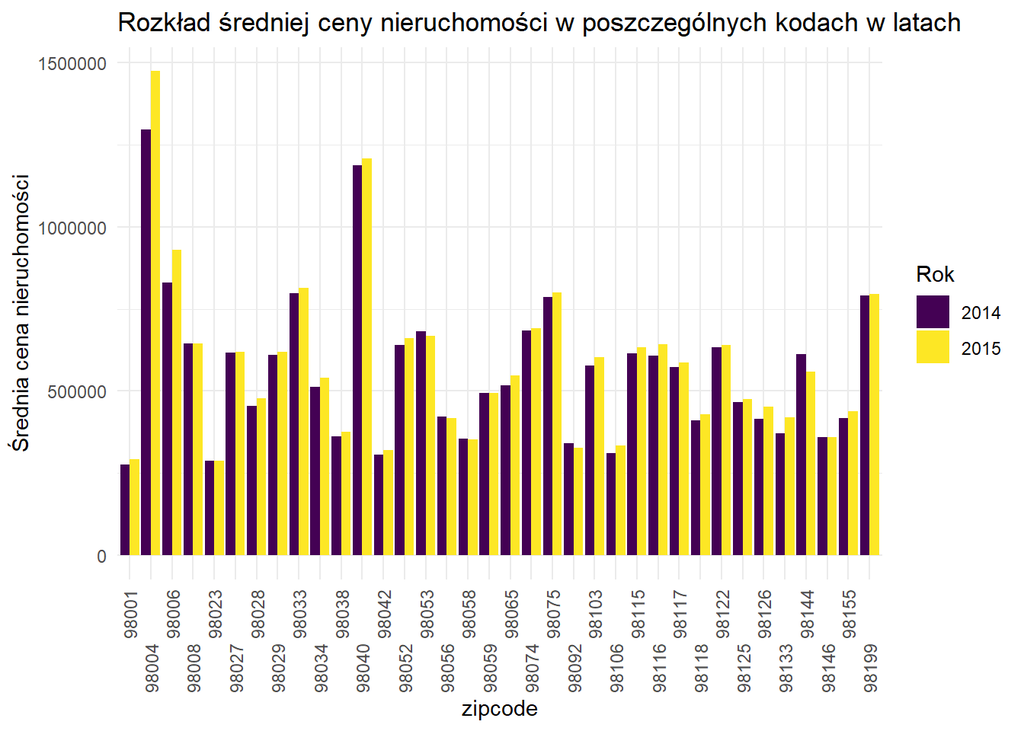

```r
df %>%
  group_by(zipcode) %>%
  summarise(count=n()) %>%
  filter(count>280) ->zipcodes280

zipcodes280$zipcode->zipcodes280

df %>%
  filter(zipcode %in% zipcodes280) %>%
  mutate(year=substring(date,1,4)) %>%
  group_by(zipcode,year) %>%
  summarise(srednia_cena=mean(price))->groupeddf

wykres1<-groupeddf %>%
ggplot(aes(x = factor(zipcode), y = srednia_cena, fill = year)) +
  geom_col(position = "dodge") +
  labs(x = "Kod pocztowy", y = "Średnia cena nieruchomości",
       title = "Rozkład średniej ceny nieruchomości w poszczególnych kodach w latach") +
  scale_x_discrete(guide=guide_axis(n.dodge = 2,title = "zipcode",angle=90))+
  scale_fill_viridis_d(name = "Rok")+
  theme_minimal()
wykres1
```

**Komentarz: Analizując wykres możemy powiedzieć, że w znacznej większości nieruchomości ich średnia cena w 2015 roku w stosunku do 2014 roku wzrosła.**

## Zadanie 2

Czy jest różnica w rozkładzie ceny nierchomości od powierzchni mieszkalnej uwzględniając podział na nieruchomości z piwnicą i bez?

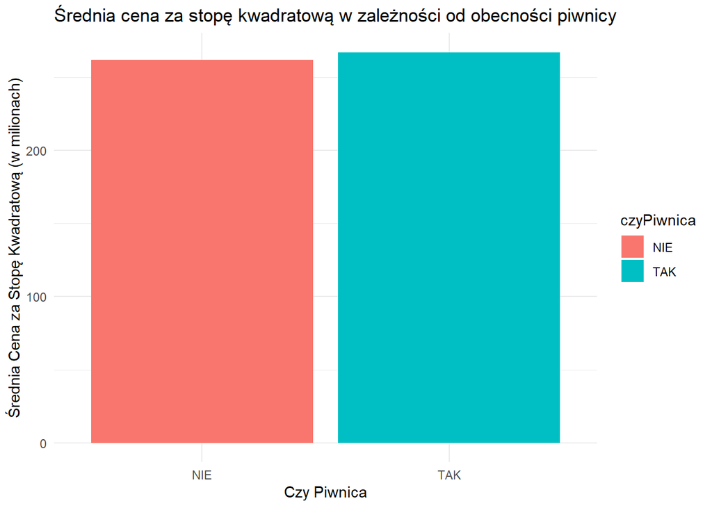

```r
wykres2<-df %>%
  mutate(
    czyPiwnica = ifelse(sqft_basement > 0, "TAK", "NIE"),
    cenaZaStopeKwadratowa = price / sqft_living
  ) %>%
  group_by(czyPiwnica) %>%
  summarize(sredniaCenaZaStopeKwadratowa = mean(cenaZaStopeKwadratowa, na.rm = TRUE)) %>%
  ggplot(aes(x = czyPiwnica, y = sredniaCenaZaStopeKwadratowa,fill=czyPiwnica)) +
  geom_col() +
  labs(
    x = "Czy Piwnica",
    y = "Średnia Cena za Stopę Kwadratową (w milionach)",
    title = "Średnia cena za stopę kwadratową w zależności od obecności piwnicy"
  )+
  theme_minimal()
wykres2
```

**Komentarz:Tak jest różnica, nieruchomosci z piwnicą, statystycznie mają wyższą cenę nieruchomości w przeliczeniu na stopę kwadratową.**

## Zadanie 3

Jaka jest zależność pomiędzy jakością wykończenia nieruchomości a liczbą pięter?

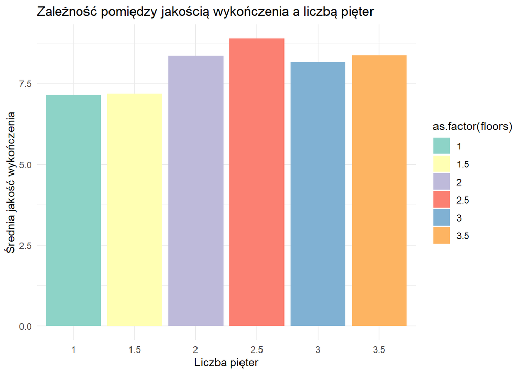

```r
library(dplyr)
library(ggplot2)

average_quality <- df %>%
  group_by(floors) %>%
  summarise(mean_quality = mean(grade, na.rm = TRUE))

wynik3<-ggplot(average_quality, aes(x = as.factor(floors), y = mean_quality, fill = as.factor(floors))) +
  geom_bar(stat = "identity") +
  labs(x = "Liczba pięter", y = "Średnia jakość wykończenia",
       title = "Zależność pomiędzy jakością wykończenia a liczbą pięter") +
  scale_fill_brewer(palette = "Set3") +
  theme_minimal()
wynik3
```

**Komentarz: Domy o małej ilości pięter są gorzej wykończone, najlepiej są wykończone domy o ilości pięter 2.5**

## Zadanie 4

Jaka jest zależność między powierzchnią mieszkalną nieruchomości a powierzchnią gruntu w podziale na liczbę sypialni?

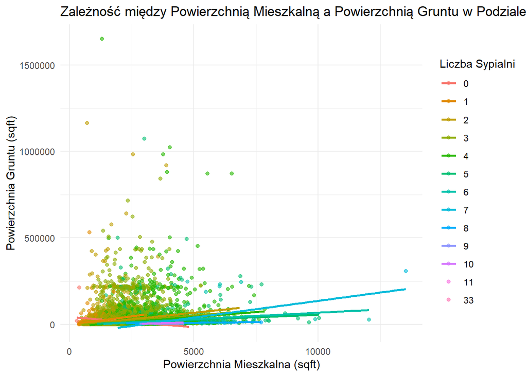

```r
wynik4<-df %>%
  ggplot(aes(x = sqft_living, y = sqft_lot, color = as.factor(bedrooms))) +
  geom_point(alpha = 0.6) +
  geom_smooth(method = "lm", se = FALSE) +
  labs(
    x = "Powierzchnia Mieszkalna (sqft)",
    y = "Powierzchnia Gruntu (sqft)",
    color = "Liczba Sypialni",
    title = "Zależność między Powierzchnią Mieszkalną a Powierzchnią Gruntu w Podziale na Liczbę Sypialni"
  ) +
  scale_fill_brewer(palette = "Set3") +
  theme_minimal()
wynik4
```

**Komentarz: Widać, że nie ma wyraźnej liniowej zależności pomiędzy powierzchnią mieszkalną a powierzchnią gruntu dla różnych liczby sypialni. Można zauważyć, że wraz ze wzrostem powierzchni mieszkalnej rośnie powierzchnia gruntu.**

## Zadanie 5

Rozważmy tylko nieruchomości, które miały remont. W której dekadzie było najwięcej przeprowadzonych remontów? Czy w poszczególnych dekadach jest porównywalny procent nieruchmości dla każdej wartości miary jakości i wykończenia nieruchomości?

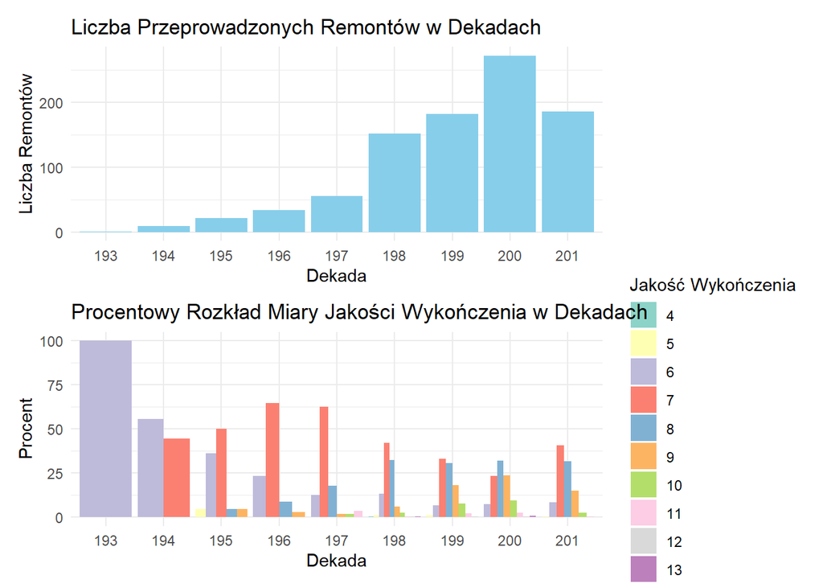

```r
library(patchwork)
df %>%
  filter(yr_renovated!=0) ->df_renovated
#1 Wykres
wynik5a<-df_renovated%>%
  mutate(dekada=substring(yr_renovated,1,3)) %>%
  group_by(dekada) %>%
  count(dekada) %>%
  ggplot(aes(x = as.factor(dekada), y = n)) +
  geom_bar(stat = "identity", fill = "skyblue") +
  labs(
    x = "Dekada",
    y = "Liczba Remontów",
    title = "Liczba Przeprowadzonych Remontów w Dekadach"
  ) +
  theme_minimal()

#2 WYKRES
wynik5b<-df_renovated%>%
  mutate(dekada=substring(yr_renovated,1,3)) %>%
  group_by(dekada, grade) %>%
  summarise(liczba = n()) %>%
  mutate(procent = liczba / sum(liczba) * 100) %>%
  ggplot(aes(x = as.factor(dekada), y = procent, fill = as.factor(grade))) +
  geom_col(position = "dodge") +
  labs(
    x = "Dekada",
    y = "Procent",
    fill = "Jakość Wykończenia",
    title = "Procentowy Rozkład Miary Jakości Wykończenia w Dekadach"
  ) +
  scale_fill_viridis_d(name = "Jakosc")+
  scale_fill_brewer(palette = "Set3") +
  theme_minimal()
wynik5<-wynik5a/wynik5b
wynik5
```

**Komentarz: Najwięcej remontów było w dekadzie 200, czyli w latach 2000-2009, w poszczegolnych dekadach procent nieruchomosci dla kazdej jakosci wykonczenia NIE jest porownywalny.**

## Zadanie 6

Jak prezentuje się wartość minimalna, średnia i maksymalna ceny nieruchmości w podziele na rok budowy nieruchomości.

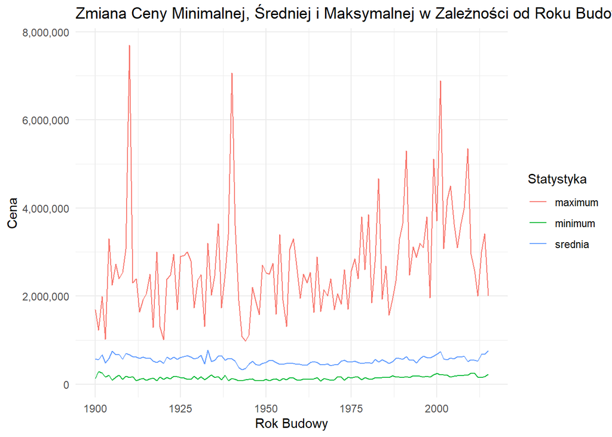

```r
library(tidyr)
library(scales)
wynik6<-df %>%
  group_by(yr_built) %>%
  summarise(minimum=min(price),srednia=mean(price),maximum=max(price)) %>%
  pivot_longer(cols = c(minimum, srednia, maximum),
               names_to = "statystyka",
               values_to = "cena") %>%
  ggplot(aes(x = yr_built, y = cena, color = statystyka, group = statystyka)) +
  geom_line() +
  scale_y_continuous(labels = label_comma()) +
  labs(
    x = "Rok Budowy",
    y = "Cena",
    color = "Statystyka",
    title = "Zmiana Ceny Minimalnej, Średniej i Maksymalnej w Zależności od Roku Budowy"
  ) +
  theme_minimal()
wynik6
```

**Komentarz: Linia czerwona reprezentująca maksymalną cenę wykazuje dużą zmienność i widoczne skoki w określonych latach. Te gwałtowne wzrosty mogą być spowodowane występowaniem pojedynczych nieruchomości o wyjątkowo wysokiej wartości, co znacząco wpływa na wartość maksymalną w danym roku.Średnia cena (linia niebieska) pozostaje stosunkowo stabilna na przestrzeni lat. Linia zielona, reprezentująca minimalne ceny, jest bardzo niska w porównaniu do średnich i maksymalnych wartości.**